# R Community of Practice Week 3

## Building a basic bar chart

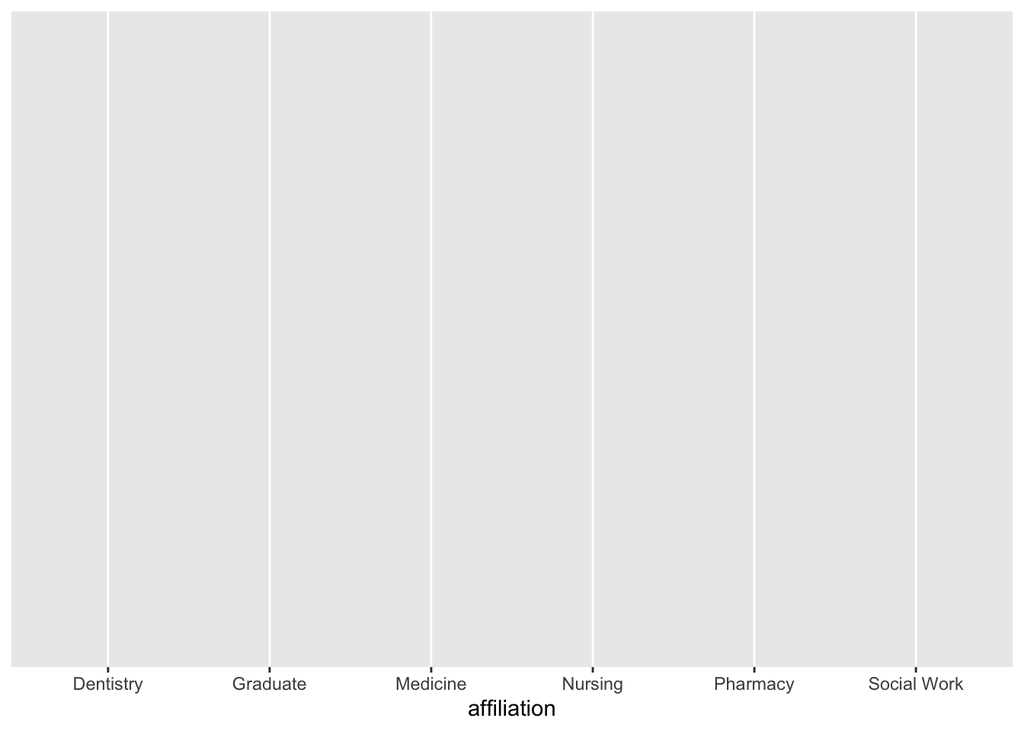

```r
all_workshops %>%
  ggplot(mapping=aes(x=affiliation))
```

Next we need to add `‘geoms’` – graphical representations of the data in the plot (points, lines, bars). **`ggplot2`** offers many different geoms for common graph types. To add a geom to the plot use the `+` operator.

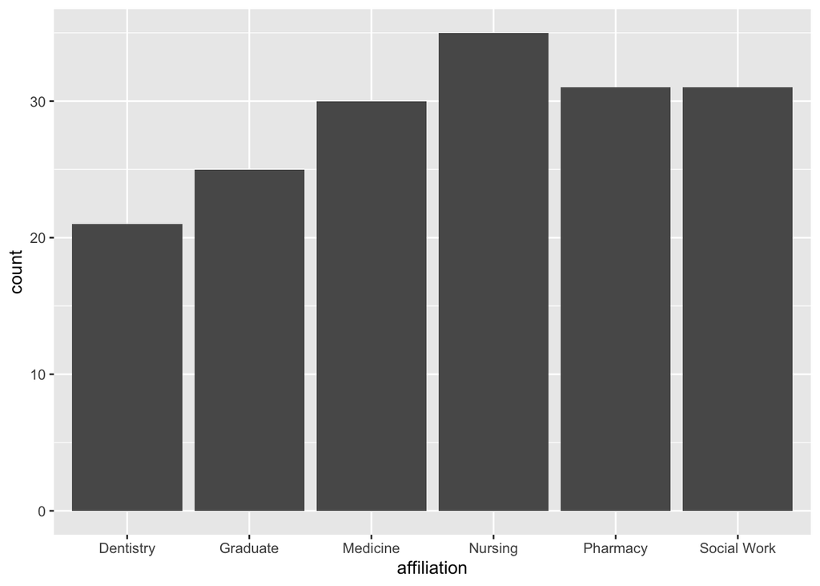

```r
all_workshops %>%
  ggplot(mapping=aes(x=affiliation)) +
  geom_bar()
```

By default bar graphs will display the count of the x variable, but it is also possible to specify a y variable that contains the count, as we do in our summarized dataset `workshop_breakdown`.

In this case, we would want to be able to specify `affiliation` as the x variable and `n` as the y variable.

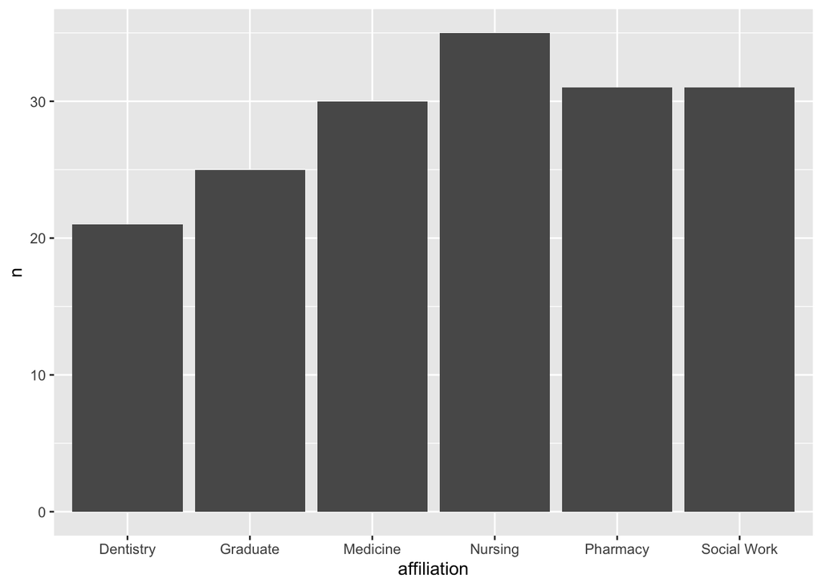

```r
workshop_breakdown %>%
  ggplot(mapping = aes(x=affiliation, y=n)) +
  geom_bar(stat="identity")
```

You need to make one other adjustment, and change the stat argument from it’s default of “count” to “identity” This tells it to base the y axis on the specified variable.

## Setting vs mapping aesthetics

When working with **`ggplot2`**, it’s important to understand the difference between *setting* aesthetic properties and *mapping* them. All geoms have certain visual attributes that can be modified. Polygons like bars, have the properties fill and color. You can change the inside color of a bar with `fill`, and the border with `color`. We can modify the defaults with the `fill` and `color` arguments in the `geom_bar()` layer. (I’ve also increased the `linewidth` to make it easier to see the border color)

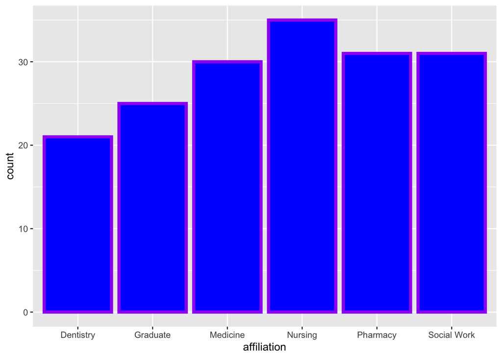

```r
all_workshops %>%
  ggplot(mapping=aes(x=affiliation)) +
  geom_bar(fill="blue", color="purple", linewidth=1.5)
```

**Note**

How did we know the color names “blue” and “purple” would work in the code above? R has 657 (!!) built in color names. You can see them by calling the function `colors()`. You can also specify colors using rgb and hexadecimal codes.

Now we have manually set a value for the fill and color. To create our initial graph, we used the `mapping` argument and the `aes()` function to map the x axis to the affiliation variable. Watch what happens if we map the fill property to the affiliation variable as well.

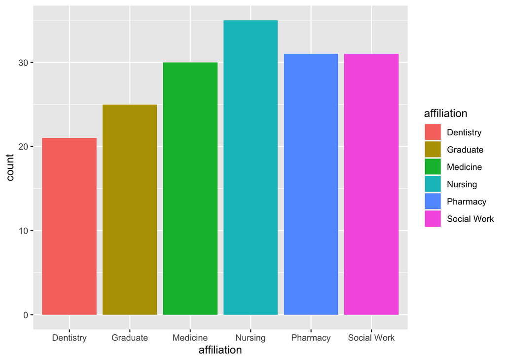

```r
all_workshops %>%
  ggplot(mapping=aes(x=affiliation, fill=affiliation)) +
  geom_bar()
```

## Building a grouped bar chart

Mapping a variable to an aesthetic is especially useful when we have third variable we want to express on our graph. For example, what if we want to compare attendance by both affiliation and status? To do this we can create a grouped bar chart by mapping `fill` to the `status` variable.

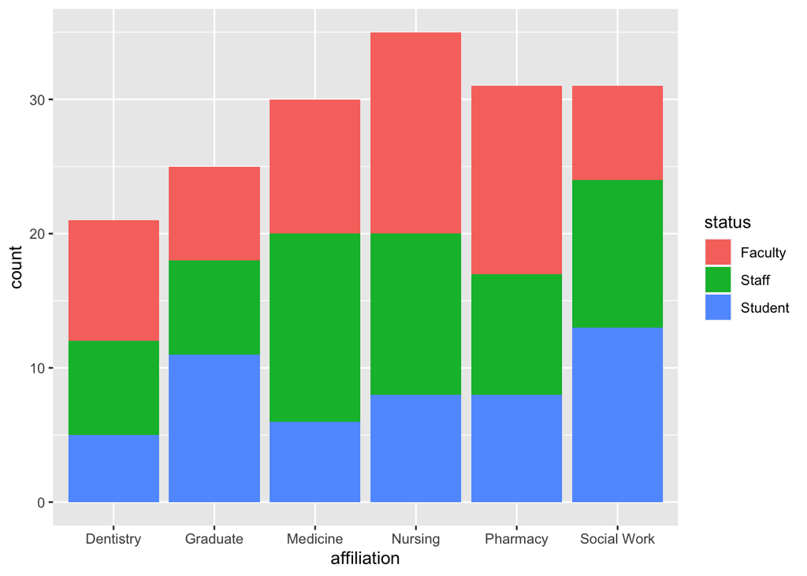

```r
all_workshops %>%
  ggplot(mapping=aes(x=affiliation, fill=status)) +
  geom_bar()
```

**Note**

When you map an aesthetic with `aes()` in the `ggplot()` function it is inherited by all subsequent layers. When you map in a `geom_*()` function it is applied only to that layer.

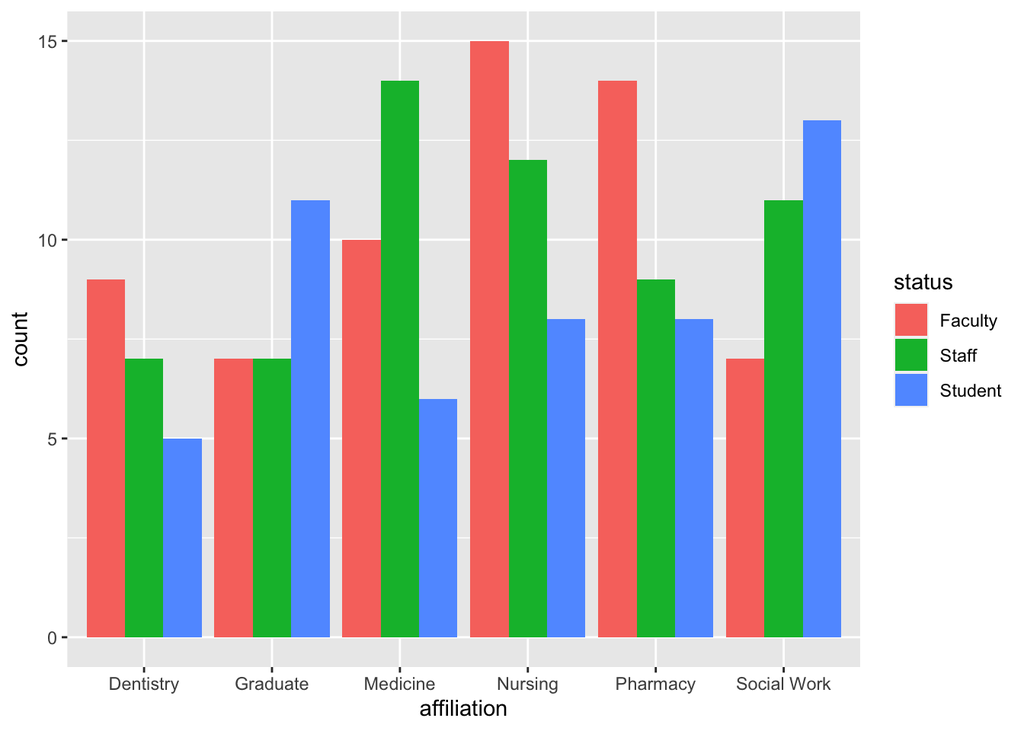

```r
all_workshops %>%
  ggplot(mapping=aes(x=affiliation, fill=status)) +
  geom_bar(position = "dodge")
```

To make our graph look less crowded, we can also modify the width of the bars. Note this is done outside of the `aes()` function.

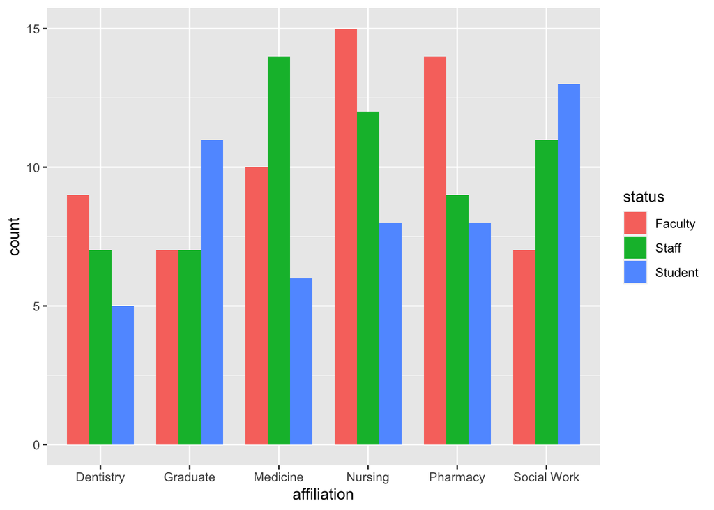

```r
all_workshops %>%
  ggplot(mapping=aes(x=affiliation, fill=status)) +
  geom_bar(position = "dodge", width = 0.75)
```

## Adding titles and axis labels

A good plot communicates clearly. So far we’ve talked about achieving this through the aesthetic aspects of your plot, but it’s important to make sure your graph has a clear title and axis labels as well. There are a few ways to do this in **`ggplot2`**, but one of the simplest is to use the `labs()` function.

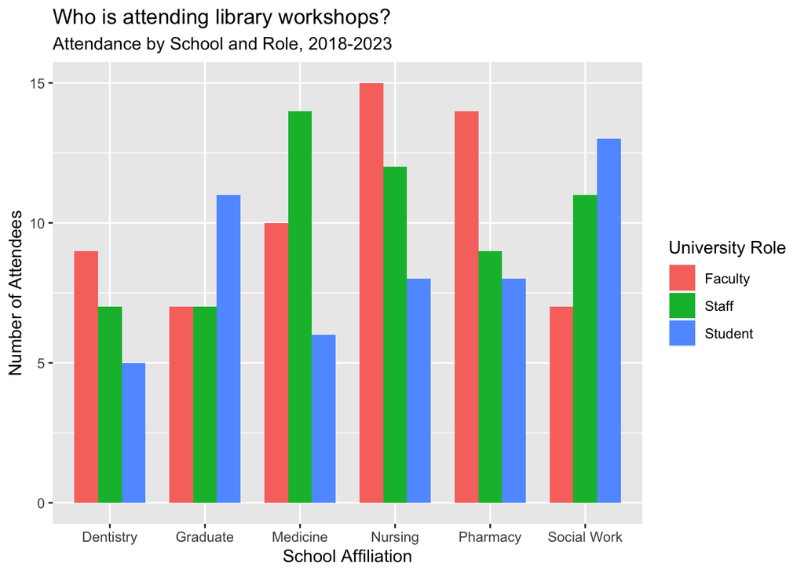

```r
all_workshops %>%
  ggplot(mapping=aes(x=affiliation, fill=status)) +
  geom_bar(position = "dodge", width = 0.75) +
  labs(title = "Who is attending library workshops?",
       subtitle = "Attendance by School and Role, 2018-2023",
       x="School Affiliation",
       y= "Number of Attendees",
       fill="University Role")
```

## Working with color palettes

There are many options for changing the color palette of your plot. You can set your palette manually:

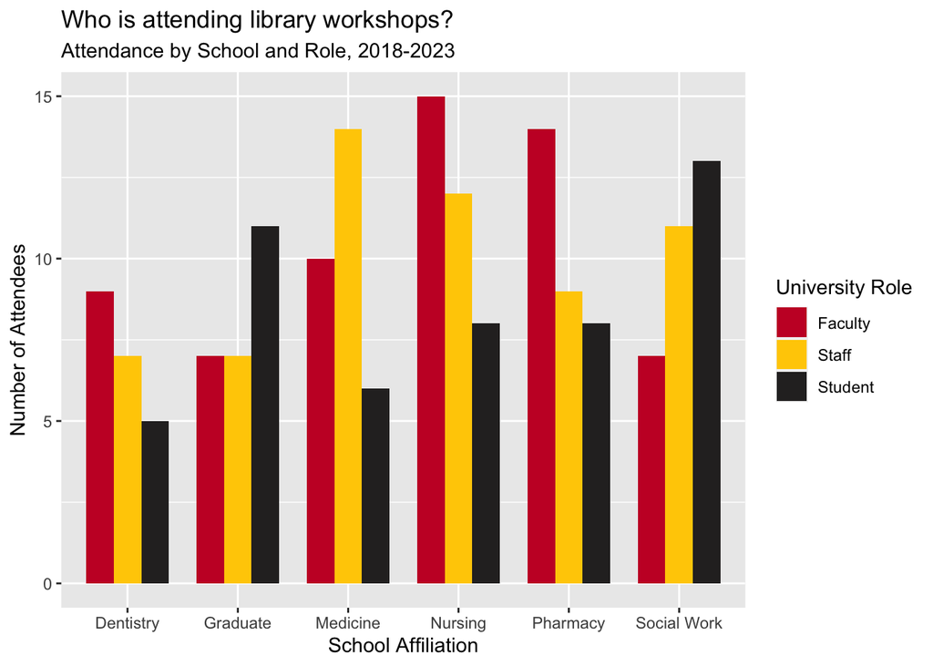

```r
myPalette <- c("#C8102E", "#FFCD00", "#2C2A29") #Official UMB colors

all_workshops %>%
  ggplot(mapping=aes(x=affiliation, fill=status)) +
  geom_bar(position = "dodge", width =0.75) +
  labs(title = "Who is attending library workshops?",
       subtitle = "Attendance by School and Role, 2018-2023",
       x="School Affiliation", y= "Number of Attendees",
       fill="University Role") +
  scale_fill_manual(values = myPalette)
```

Generally, it may be preferable to work with one of the built in **`ggplot2`** or R palettes, or to install one of several packages with additional palettes such as:

- [**`RColorBrewer`**](https://r-graph-gallery.com/38-rcolorbrewers-palettes.html)
- [**`viridis`**](https://cran.r-project.org/web/packages/viridis/vignettes/intro-to-viridis.html)
- [**`ggthemes`**](https://yutannihilation.github.io/allYourFigureAreBelongToUs/ggthemes/)
- [**`ggsci`**](https://cran.r-project.org/web/packages/ggsci/vignettes/ggsci.html)
- [**`wesanderson`**](https://github.com/karthik/wesanderson#readme)

Let’s try applying a **`viridis`** palette. **`viridis`** was designed to be especially robust for many forms of color-blindness. It is also meant to print well in grey scale. As an additional advantage, a lightweight form of the package is included with **`ggplot2`**, so there is no need to install additional packages.

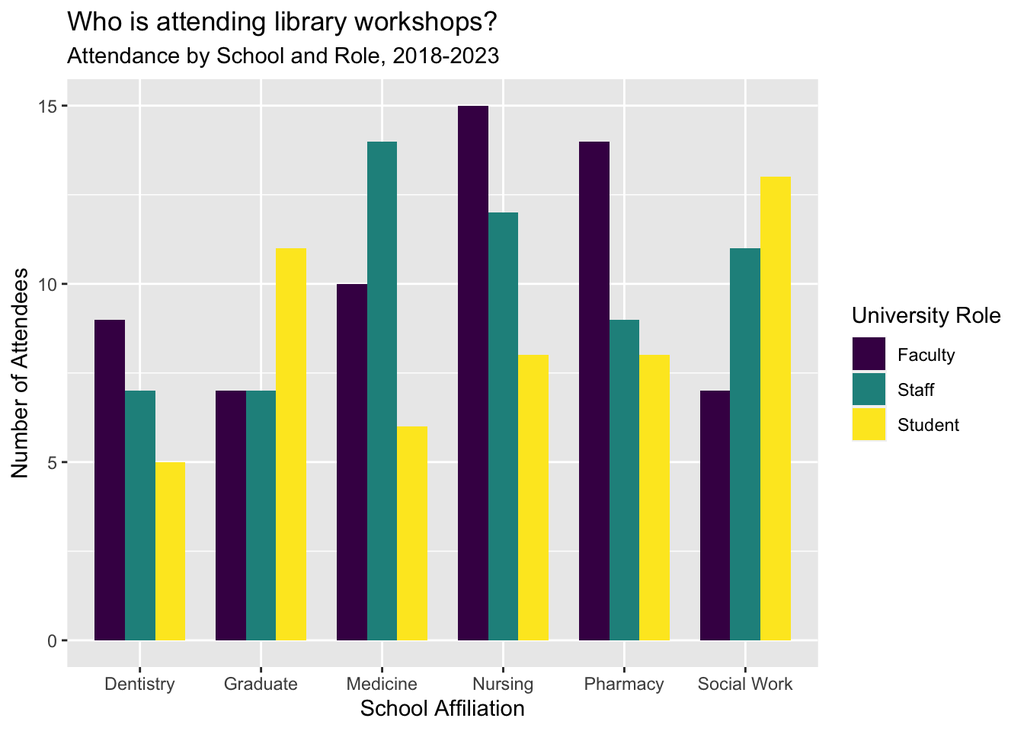

```r
all_workshops %>%
  ggplot(mapping=aes(x=affiliation, fill=status)) +
  geom_bar(position = "dodge", width = 0.75) +
  labs(title = "Who is attending library workshops?",
       subtitle = "Attendance by School and Role, 2018-2023",
       x="School Affiliation",
       y= "Number of Attendees",
       fill="University Role") +
  scale_fill_viridis_d()
```

Learn more from the [**`viridis`** documentation](https://cran.r-project.org/web/packages/viridis/vignettes/intro-to-viridis.html#the-color-scales)

## Changing the theme

The theme of a **`ggplot2`** graph controls the overall look and all non-data elements of the plot. There are several built-in themes which can be applied as another layer. Start typing `theme_` in RStudio to see a list of themes. You can also use the `theme()` function to modify aspects of an existing theme. Here we apply `theme_classic()` which removes the grid lines and grey background of the default theme.

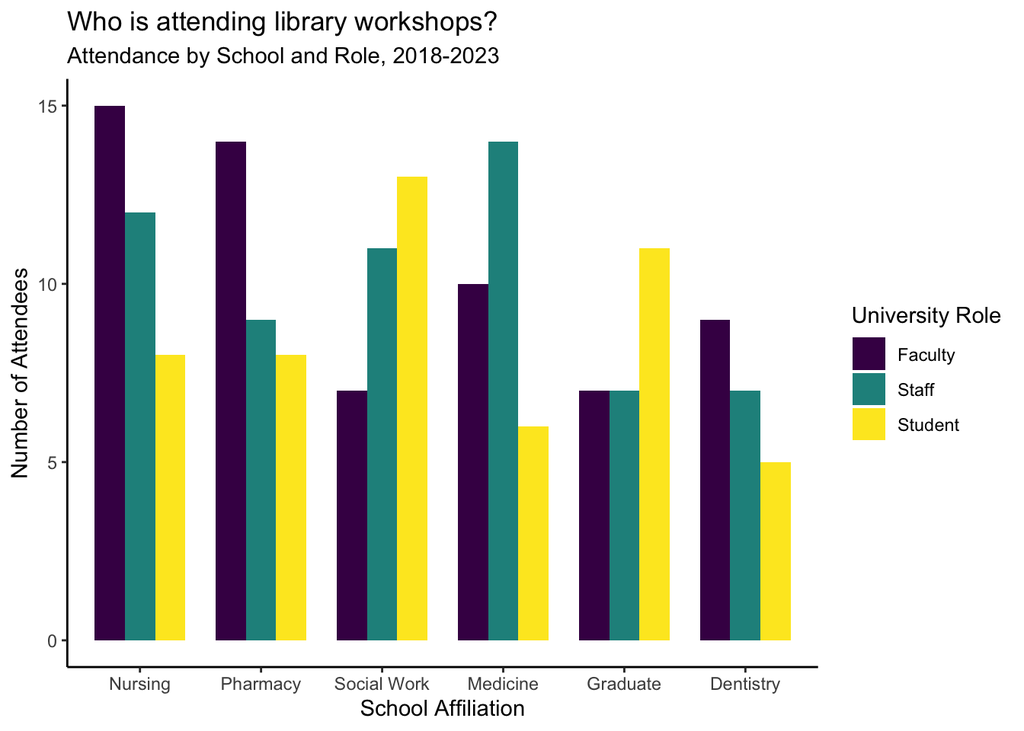

```r
all_workshops %>%
  ggplot(mapping=aes(x=fct_infreq(affiliation), fill=status)) +
  geom_bar(position = "dodge", width = 0.75) +
  labs(title = "Who is attending library workshops?",
       subtitle = "Attendance by School and Role, 2018-2023",
       x="School Affiliation",
       y= "Number of Attendees",
       fill="University Role") +
  scale_fill_viridis_d() +
  theme_classic()
```

## Wrapping Up

Once your plot looks the way you want, you may want to export it to an image file for use in another document (although in Week 6 we’ll learn how to build reports with plots directly in RStudio).

There are two ways to export your plot:

1. Use the Export widget in the Plots pane of RStudio
2. Use the `ggsave()` function

Let’s first save the grouped bar chart as an object:

```r
workshop_attendance_bar <- all_workshops %>%
  ggplot(mapping=aes(x=fct_infreq(affiliation), fill=status)) +
  geom_bar(position = "dodge", width = 0.75) +
  labs(title = "Who is attending library workshops?",
       subtitle = "Attendance by School and Role, 2018-2023",
       x="School Affiliation",
       y= "Number of Attendees",
       fill="University Role") +
  scale_fill_viridis_d() +
  theme_classic()
```

Now use `ggsave()` to save a .jpg version of your plot to your `figs/` directory. The only required argument is the file path where you want to save the image. By default it will save the last plot generated, but you can also supply the object name of the plot you want to save.

```r
ggsave(filename = "figs/workshop_attendance_bar.jpg", workshop_attendance_bar)
```

Note that you can also use this function to adjust the size and resolution of you graph.

```r
ggsave(filename = "figs/workshop_attendance_bar.jpg", workshop_attendance_bar, width = 7, height = 5, dpi = 300)
```

## Helpful Resources

### Background and Overview

- [**`ggplot2`** documentation](https://ggplot2.tidyverse.org/)
- [R for Data Science](https://r4ds.had.co.nz/)
  - [Chapter 3, “Data Visualization”](https://r4ds.had.co.nz/data-visualisation.html)
  - [Chapter 28, “Graphics for Communication”](https://r4ds.had.co.nz/graphics-for-communication.html)

### Tutorials for Many Kinds of Plots

- [R Graph Gallery](https://r-graph-gallery.com/)
- [R Graphics Cookbook](https://r-graphics.org/)

### Working with Color and Other Aesthetics

- [R Graph Gallery Color Section](https://r-graph-gallery.com/ggplot2-color.html)
- [Paletteer package](https://github.com/EmilHvitfeldt/paletteer#readme)
- [**`ggplot2`** Aesthetic Specifications](https://ggplot2.tidyverse.org/articles/ggplot2-specs.html)